# SECRET example

JS

Disclaimer (5/8/26): this is still WIP, and some functionality may slightly change.

A worked example using the pulmonary model from the SECRET competition.

Load in design, data:

```r
setwd('..')
tmp <- getwd()
source(paste0(tmp, '/plot.R'))
source(paste0(tmp, '/basis.R'))
source(paste0(tmp, '/emulate.R'))
source(paste0(tmp, '/calibrate.R'))
load(paste0(tmp, '/data/SECRET_data.RData'))
# Currently need to load ggplot2 explicitly
library(ggplot2)
```

Parameter ranges, and hence scaling the design to [0,1]:

```r
parRanges
```

```
##    Name   Lower   Upper
## 1   kMV 9.0e+04 3.0e+05
## 2 alpha 8.3e-01 8.9e-01
## 3  lrrA 2.0e+01 5.0e+01
## 4  lrrV 2.0e+01 5.0e+01
```

```r
scaled_design <- ScaleInputs(design[,1:4], parRanges, c(0,1))
```

## Single 1D profile

First let’s consider only the first output, and process the data into a `DataBasis` object:

```r
DataBasis <- MakeDataBasis(flow1_data)
```

We can now plot various aspects using the functionality of the package. Plotting the full ensemble:

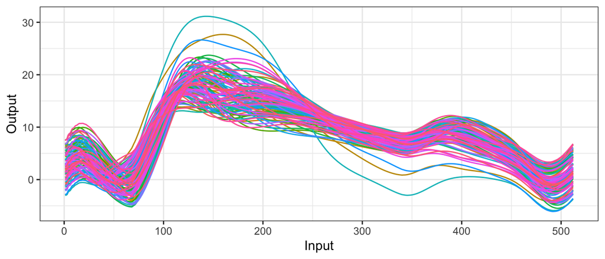

```r
PlotData(DataBasis)
```

Plotting the leading 4 basis vectors:

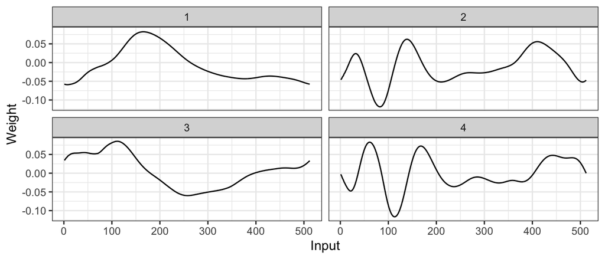

```r
PlotBasis(DataBasis, q = 4)
```

Everything will work fine and treat inputs as 1:512, but by assigning a data frame to `$grid`, we can relabel:

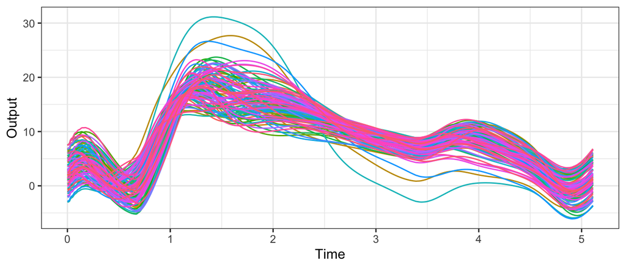

```r
DataBasis$grid <- data.frame(Time = seq(from=0, by = 0.01, len = 512))
PlotData(DataBasis)
```

## Multiple 1D profiles

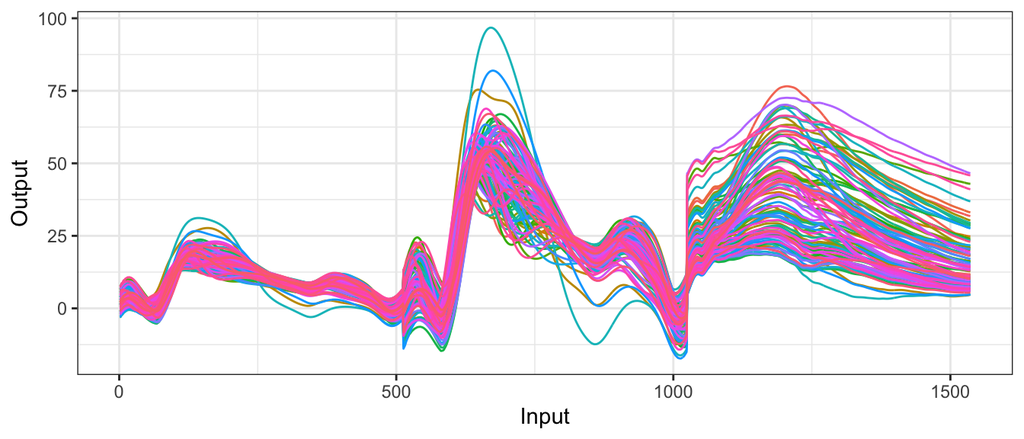

```r
DataBasis_multi <- MakeDataBasis(pulm_data)
PlotData(DataBasis_multi)
```

This is not a particularly useful visualisation, but by assigning time/variable names in a grid, the same code will automatically plot according to this:

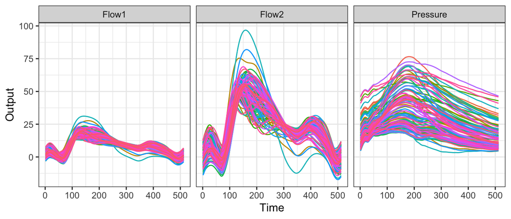

```r
DataBasis_multi$grid <- data.frame(Time = 1:512,
                              Output = c(rep('Flow1', 512), rep('Flow2', 512), rep('Pressure', 512)))
PlotData(DataBasis_multi)
```

Or the basis:

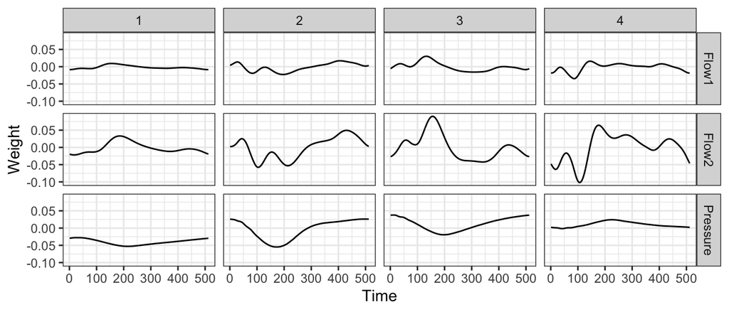

```r
PlotBasis(DataBasis_multi, q = 4)
```

## Emulation

As an initial demonstration, select a few particular timepoints from Flow1. Combining the (scaled) inputs with the outputs for 4 different timepoints:

```r
flow1_time <- data.frame(scaled_design,
                         t50 = flow1_data[50,],
                         t150 = flow1_data[150,],
                         t300 = flow1_data[300,],
                         t500 = flow1_data[500,])
```

Splitting into training and validation sets:

```r
tt <- TrainTestSplit(scaled_design, seed = 58219)
train_inds <- tt$train_inds
val_inds <- tt$val_inds
```

More details are provided in `emulate.html`, but briefly, we can fit a single emulator by providing a single named output, and pointing to which columns we want to be treated as inputs:

```r
em_t150 <- FitEmulators(flow1_time[train_inds,], input = 1:4, output = 't150')
```

```r
summary(em_t150)
```

```
##            Length Class      Mode
## em         1      rgasp      S4
## method     1      -none-     character
## response   1      -none-     character
## mean_fn    1      -none-     character
## train_data 5      data.frame list
```

This has stored an `rgasp` emulator under `$em`, what mean function was used (here none, hence `NULL`), and also what the training data was (including only the selected inputs and output, rather than the full given `tData`).

To look at the emulator predictions, we could plot leave one outs:

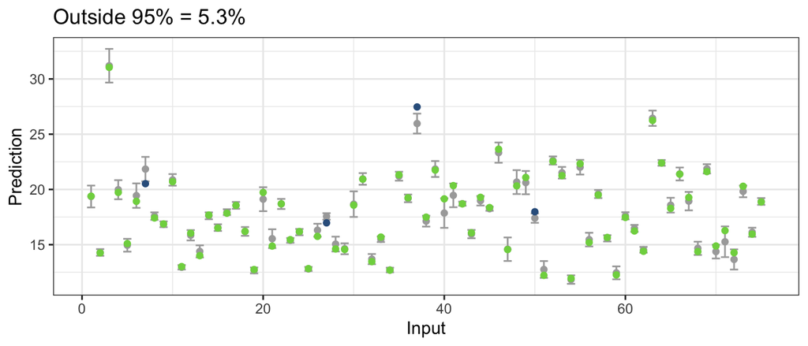

```r
LeaveOneOut(em_t150, by_index = TRUE)
```

Or predict over the validation set:

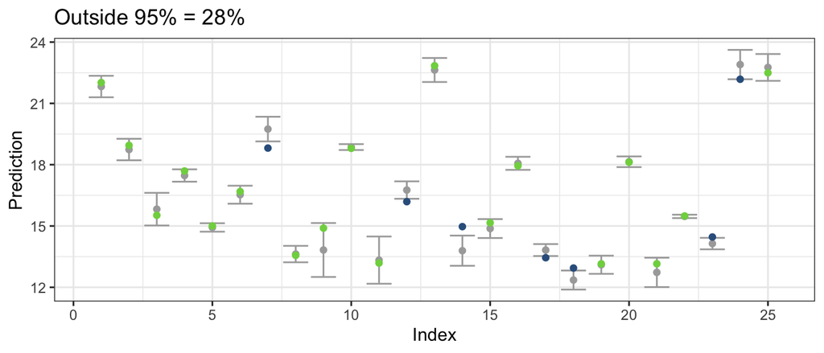

```r
Validate(em_t150, flow1_time[val_inds,], by_index = TRUE)
```

We could also plot vs the inputs:

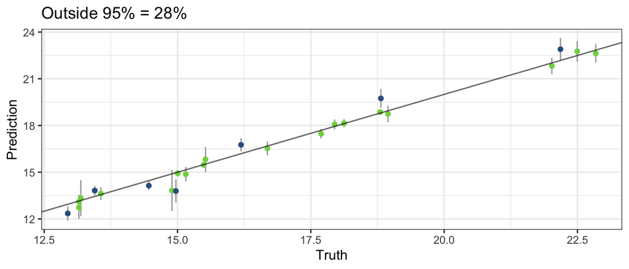

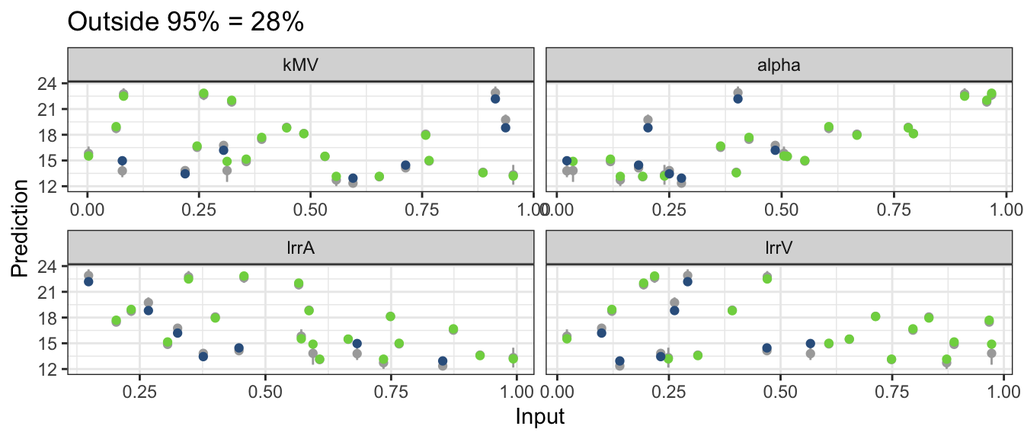

```r
Validate(em_t150, flow1_time[val_inds,], by_input = TRUE)
```

## Emulate multiple outputs

The same code can be used to emulate all 4 of the chosen outputs independently:

```r
em_time <- FitEmulators(flow1_time[train_inds,], input = 1:4, output = c('t50', 't150', 't300', 't500'))
```

Now the fitted `em_time` is a list of 4 individual emulators:

```r
summary(em_time)
```

```
##      Length Class  Mode
## [1,] 5      -none- list
## [2,] 5      -none- list
## [3,] 5      -none- list
## [4,] 5      -none- list
```

```r
summary(em_time[[1]])
```

```
##            Length Class      Mode
## em         1      rgasp      S4
## method     1      -none-     character
## response   1      -none-     character
## mean_fn    1      -none-     character
## train_data 5      data.frame list
```

The `Validate` and `LeaveOneOut` functions work with lists of emulators as well:

```r
loo_time <- LeaveOneOut(em_time, by_index = TRUE)
```

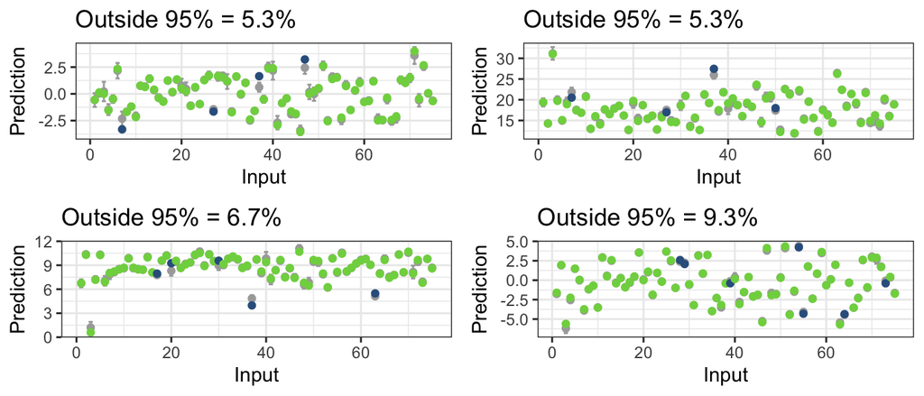

```r
val_time <- Validate(em_time, flow1_time[val_inds,], by_index = TRUE)
```

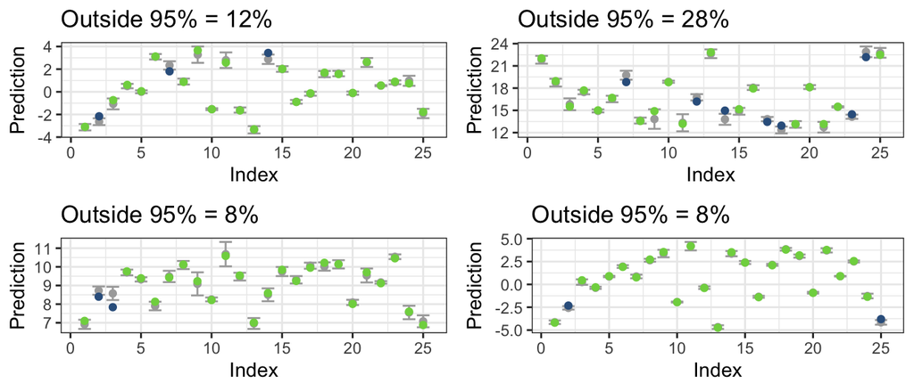

## Predictions

Predictions work the same for each type of emulator. Providing a set of 5000 points sampled from input space:

```r
set.seed(58219)
BigDesign <- lhs::randomLHS(5000,4)
colnames(BigDesign) <- colnames(scaled_design)
preds_t150 <- Predict(em_t150, BigDesign)
preds_time <- Predict(em_time, BigDesign)
```

The `Predict` function outputs `$Expectation` and `$Variance`, with the number of rows equal to the number of prediction points (here, 5000), and the number of columns equal to the number of emulators:

```r
summary(preds_t150)
```

```
##             Length Class  Mode
## Expectation 5000   -none- numeric
## Variance    5000   -none- numeric
```

```r
summary(preds_time)
```

```
##             Length Class  Mode
## Expectation 20000  -none- numeric
## Variance    20000  -none- numeric
```

```r
dim(preds_t150$Expectation)
```

```
## [1] 5000    1
```

```r
dim(preds_time$Expectation)
```

```
## [1] 5000    4
```

## Calibration

Let’s assume some ‘observations’. Run 100 from the initial design wasn’t used in training the emulators, so we’ll set this as the target:

```r
obs <- flow1_data[,100]
truth <- scaled_design[100,]
```

We can calculate the implausibility for an individual output, given a set of predictions, and given observation error variance (here, set at 0.5) and discrepancy variance (defaults to zero, as could provide combined with the observation error):

```r
impl_t150 <- Impl(preds_t150, Obs = obs[150], ObsVar = 0.5, DiscVar = 0, kmax = 1)
```

Or for multiple outputs (independently):

```r
impl_time <- Impl(preds_time, Obs = obs[c(50,150,300,500)], ObsVar = 0.5, DiscVar = 0, kmax = 1)
```

Where we have now provided 4 sets of predictions and 4 observations. `ObsVar` (and `DiscVar`) has still been set as a single value, which is interpreted as each observation has the same observational error. Instead, this could be provided as a vector of length 4:

```r
#impl_time <- Impl(preds_time, Obs = obs[c(50,150,300,500)], ObsVar = c(0.5, 0.1, 1, 0.5), DiscVar = c(0, 1, 0.2, 0), kmax = 1)
```

Although prediction and calculating implausibility can be done by hand as above, usually it will be more convenient to combine them:

```r
hm_time <- HistoryMatch(em_time, BigDesign, Obs = obs[c(50,150,300,500)], ObsVar = 0.5, kmax = 1)
summary(hm_time)
```

```
##           Length Class      Mode
## Impl      20000  -none-     numeric
## threshold     1  -none-     numeric
## NROY          1  -none-     numeric
## Pass_kth      4  -none-     numeric
## Pass_N        5  -none-     numeric
## inNROY     5000  -none-     logical
## Design        5  data.frame list
## Preds         2  -none-     list
## wave          1  -none-     numeric
```

There’s several outputs returned by this function:

- `$Design` is the same as the given design, but with a column appended indicating whether each point is in NROY space or not.
- `$Preds` contains the emulator predictions at the given design.
- `$Impl`, `$NROY`, `$Pass_kth`, `$Pass_N`, `$inNROY` and `$wave` are related to the calibration part. The implausibility itself, for each provided input vector and each observation:

```r
head(hm_time$Impl)
```

```
##           [,1]      [,2]      [,3]      [,4]
## [1,] 0.7155879 1.3086590 1.5967053 0.5334258
## [2,] 2.1530824 6.5496570 1.4951001 7.2901905
## [3,] 2.4550439 0.3616181 2.9678143 0.7558482
## [4,] 1.2799018 1.8166300 2.2715913 2.3174949
## [5,] 1.6540927 3.1207935 0.1333359 0.9133111
## [6,] 5.3443558 0.9794073 2.9029753 3.0973984
```

The proportion of space not ruled out:

```r
hm_time$NROY
```

```
## [1] 0.204
```

The proportion of space that satisfies the kth constraint:

```r
hm_time$Pass_kth
```

```
## [1] 0.6702 0.4246 0.8324 0.5274
```

The proportion of space that passes 0, 1, 2, 3, 4 out of 4 constraints:

```r
hm_time$Pass_N
```

```
##      0      1      2      3      4
## 0.0698 0.0976 0.3448 0.2838 0.2040
```

Whether each row of the design is in NROY:

```r
head(hm_time$inNROY)
```

```
## [1]  TRUE FALSE  TRUE  TRUE FALSE FALSE
```

As a demonstration that what’s happening within the `HistoryMatch` function is identical to what we did previously, the predictions are the same:

```r
summary(hm_time$Preds$Expectation - preds_time$Expectation)
```

```
##        V1          V2          V3          V4
##  Min.   :0   Min.   :0   Min.   :0   Min.   :0
##  1st Qu.:0   1st Qu.:0   1st Qu.:0   1st Qu.:0
##  Median :0   Median :0   Median :0   Median :0
##  Mean   :0   Mean   :0   Mean   :0   Mean   :0
##  3rd Qu.:0   3rd Qu.:0   3rd Qu.:0   3rd Qu.:0
##  Max.   :0   Max.   :0   Max.   :0   Max.   :0
```

As is the implausibility:

```r
summary(hm_time$Impl - impl_time$Impl)
```

```
##        V1          V2          V3          V4
##  Min.   :0   Min.   :0   Min.   :0   Min.   :0
##  1st Qu.:0   1st Qu.:0   1st Qu.:0   1st Qu.:0
##  Median :0   Median :0   Median :0   Median :0
##  Mean   :0   Mean   :0   Mean   :0   Mean   :0
##  3rd Qu.:0   3rd Qu.:0   3rd Qu.:0   3rd Qu.:0
##  Max.   :0   Max.   :0   Max.   :0   Max.   :0
```

Taking the output, we can visualise the NROY space in 1D and 2D, with the truth overlaid:

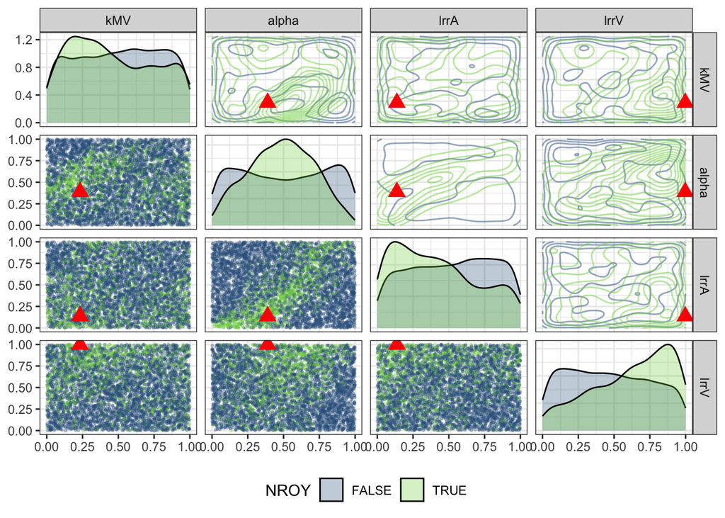

```r
PlotNROY(hm_time$Design, k = 1:4, Truth = truth)
```

A multiwave example, using both scalar outputs and higher dimensional, correlated outputs, is found in `systemic.html`.

## Emulate full output

Now we’ll use dimension reduction to emulate the full Flow1 output curve.

We already have the required `DataBasis` object (calculated at the start to simplify plotting):

```r
summary(DataBasis)
```

```
##              Length Class      Mode
## tBasis       50688  -none-     numeric
## CentredField 51200  -none-     numeric
## EnsembleMean   512  -none-     numeric
## Coeffs        9900  -none-     numeric
## Q                0  -none-     NULL
## Lambda           0  -none-     NULL
## grid             1  data.frame list
```

This already contains the projections of the (centered) data onto the basis vectors:

```r
dim(DataBasis$Coeffs)
```

```
## [1] 100  99
```

As an illustration, we’ll select the leading 5 basis vectors arbitrarily, but more or fewer might perform better. Combining these coefficients with the design:

```r
tDataCoeffs <- GetEmData(scaled_design, DataBasis, q = 5)
head(tDataCoeffs)
```

```
##         kMV      alpha       lrrA      lrrV         C1         C2         C3
## 1 0.2947210 0.08288013 0.62378109 0.3207808 -57.654972 -21.804896   9.724607
## 2 0.9652367 0.06777972 0.38185132 0.6951411 -20.741136 -32.018533  -9.987071
## 3 0.6105418 0.69884483 0.05439422 0.8660534  47.747129   1.772807 -19.527830
## 4 0.1562447 0.01730095 0.31641006 0.5044971 -51.121585  -7.456377  15.738800
## 5 0.6351484 0.63567131 0.55211716 0.1662941  21.977666 -18.626407  -6.811848
## 6 0.3784997 0.73657700 0.72578984 0.3711951  -5.173414  21.054044  -2.062772
##           C4        C5
## 1   1.470627 -6.743898
## 2  10.134155  6.463637
## 3  -6.458404  8.086397
## 4 -13.113496  2.551755
## 5  -6.335217 -9.934757
## 6  -4.182515 -2.972536
```

Training emulators for the leading 5 coefficients works in the same way as above. In fact, by default, if the code finds a column named `C1`, it will automatically treat this as the first output to emulate, and also train emulators to all subsequent columns. Hence, the below is equivalent to setting `emulate_names = c('C1', 'C2', 'C3', 'C4', 'C5')`:

```r
emCoeffs <- FitEmulators(tDataCoeffs[train_inds,], input = 1:4)
```

We have 5 emulators, one for each of the given sets of coefficients:

```r
summary(emCoeffs)
```

```
##      Length Class  Mode
## [1,] 5      -none- list
## [2,] 5      -none- list
## [3,] 5      -none- list
## [4,] 5      -none- list
## [5,] 5      -none- list
```

```r
unlist(lapply(1:5, function(k) emCoeffs[[k]]$response))
```

```
## [1] "C1" "C2" "C3" "C4" "C5"
```

Looking at LOOs and out-of-sample predictions:

```r
valCoeffs <- Validate(emCoeffs, tDataCoeffs[val_inds,], by_index = TRUE)
```

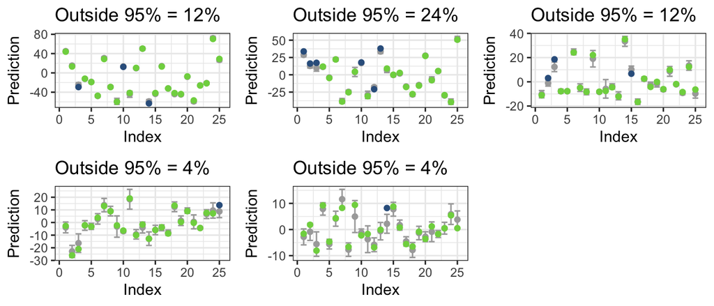

```r
looCoeffs <- LeaveOneOut(emCoeffs, by_index = TRUE)
```

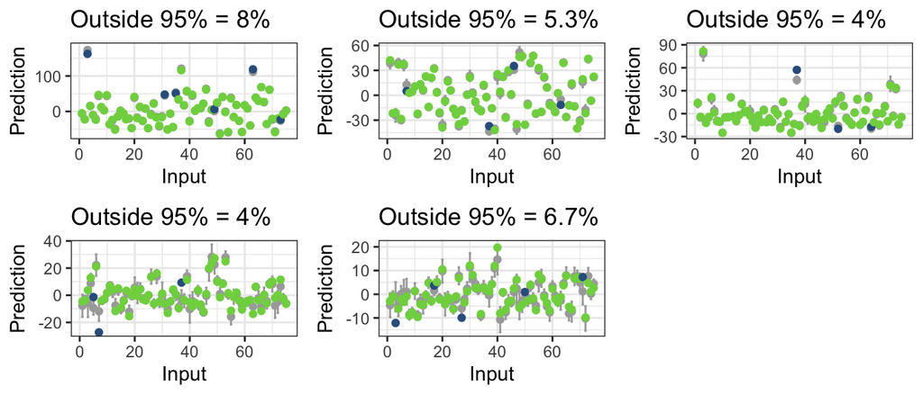

We seem to be still predicting quite well for the 5th coefficient, which suggests at least trying to emulate the next, rather than treating as noise.

Prediction is as above:

```r
predsCoeffs <- Predict(emCoeffs, BigDesign)
head(predsCoeffs$Expectation)
```

```
##           [,1]       [,2]      [,3]      [,4]       [,5]
## [1,] -20.31459  22.958632  5.416692 -2.163334  2.1694890
## [2,] -64.10608 -24.779325  1.686531 14.540757 -1.6066513
## [3,] -10.63788  33.616080  7.002753 -5.142927 -3.6276028
## [4,] -37.67619  24.847081 20.411235  1.266994  1.2051620
## [5,] -12.02403   2.152019 -7.167481 -6.290520  0.9817495
## [6,]  31.48086  10.532179 -9.870009 -8.404354 -6.7290105
```

## Calibration for the full field

As for the set of 4 individual metrics above, the function `HistoryMatch` will handle the high-dimensional calibration. Let’s do it by hand first to be clearer about what’s happening. The only difference is that instead of the 1D implausibility `Impl`, we require `ImplField`:

```r
implFull <- ImplField(predsCoeffs, DataBasis, Obs = obs, ObsVar = 0.5)
summary(implFull$Impl)
```

```
##     Min.  1st Qu.   Median     Mean  3rd Qu.     Max.
##    26.81   539.67  1211.48  1858.07  2438.20 30321.51
```

```r
implFull$threshold
```

```
## [1] 598.1784
```

```r
implFull$NROY
```

```
## [1] 0.2742
```

```r
summary(implFull$inNROY)
```

```
##    Mode   FALSE    TRUE
## logical    3629    1371
```

This function exploits the basis structure of the emulator, and in fact calculate the full 512D implausibility as the sum of the reconstruction error (fixed) and the 5D coefficient implausibility:

```r
ReconError(obs - DataBasis$EnsembleMean, DataBasis$tBasis[,1:5], scale = FALSE)
```

```
## [1] 29.57011
```

(Actually, this isn’t *quite* right, because in fact calculate it after accounting for basis uncertainty. But same general idea.)

As a check that the above decomposition is correct (it is), there’s a function that calculates the full implausibility by mapping the emulator expectation and variance back to the field. Here, this is tractable as we only have a $512\times512$ inversion for each input, but still quite slow, so only do for a few:

```r
preds_tmp <- Predict(emCoeffs, BigDesign[1:100,])
implFull_v2 <- ImplFieldRecon(preds_tmp, DataBasis, obs, ObsVar = 0.5)
summary(implFull$Impl[1:100] - implFull_v2)
```

```
##       Min.    1st Qu.     Median       Mean    3rd Qu.       Max.
## -7.276e-12 -6.821e-13 -7.105e-14 -4.931e-14  4.547e-13  7.276e-12
```

Instead directly using the `HistoryMatch` function:

```r
hmCoeffs <- HistoryMatch(emCoeffs, BigDesign, DataBasis, Obs = obs, ObsVar = 0.5)
summary(hmCoeffs$Impl)
```

```
##     Min.  1st Qu.   Median     Mean  3rd Qu.     Max.
##    26.81   539.67  1211.48  1858.07  2438.20 30321.51
```

```r
hmCoeffs$NROY
```

```
## [1] 0.2742
```

The results are exactly the same as when running `Predict` and `ImplField` separately. Plotting:

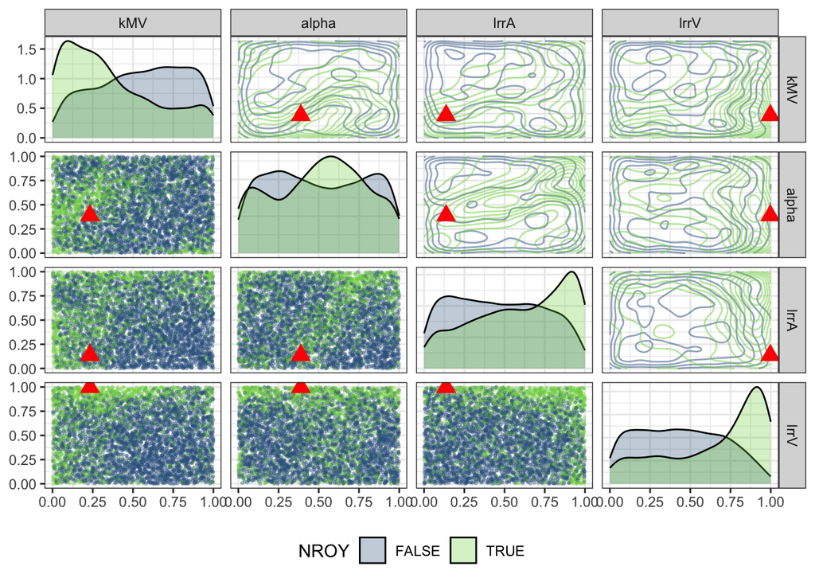

```r
PlotNROY(hmCoeffs$Design, k = 1:4, Truth = truth)
```

Although the observations are the same, these results aren’t fully comparable to those when using 4 metrics, as now using all 512 outputs, and those we didn’t consider before may provide different information.